*Lee Min Hua*

# Trending Youtube Videos EDA & Sentiment Analysis

**Founded in 2005, YouTube is one of the most popular video sharing websites today, with over 30 millions of visitors per day and 30 hours of videos uploaded every minute.**

Everyday, Youtube displays a list of trending videos for all users in each country, from a new song of a popular artist to a new movie trailer, everything in between to help them see what's happening on Youtube and around the world. In this report, I am going to do a comparative analysis on some of the datasets about Youtube trending videos in GB and US to uncover as much insights as possible such as the video preferences of GB and US audiences, audience sentiment as well as the potential factors of what makes a video trending.

## Getting Started

Loading required libraries

```r
oldw <- getOption("warn")
options(warn = -1)

library(jsonlite)
library(plyr)
library(miscTools)
library(lubridate)
library(stringr)
library(data.table)
library(ggplot2)
library(ggthemes)
library(dplyr)
library(magrittr)
library(gtable)
library(grid)
library(gridExtra)
library(reshape2)
library(plotly)
library(RColorBrewer)
library(wordcloud)
library(tm)
library(SnowballC)
library(textclean)
library(stringi)
library(corpus)
library(sentimentr)
library(scales)
library(knitr)
library(kableExtra)
library(stringr)
library(ngram)
library(IRdisplay)
library(devtools)
```

## Data Overview

We will be using three datasets for each country in the analysis. The video dataset contains details of up to 200 listed Youtube trending videos everyday for 40 consecutive days, including video title, channel name, tags, along with statistics such as views, likes, dislike and comments. The comment dataset contains comment texts of these trending videos and the category dataset contains video categories with their unique id.

Data Source: https://www.kaggle.com/datasnaek/youtube

Let's import the data file and catch a glimpse on the data.

```r
# Import gb videos data
gb_videos <- read.csv('GBvideos.csv',header=T,stringsAsFactors=F)

# Check the first rows of the dataset
head(gb_videos)
```

| video_id | title | channel_title | category_id | tags | views | likes | dislikes | comment_total | thumbnail_link | date |
| --- | --- | --- | --- | --- | --- | --- | --- | --- | --- | --- |
| jt2OHQh0HoQ | Live Apple Event - Apple September Event 2017 - iPhone 8, iPhone X, iOS 11 - Apple Keynote | Apple Event | 28 | apple events\|apple event\|iphone 8\|iphone x\|iphone 8 plus\|iphone 7s\|iphone 7s plus\|ios 11 | 7426393 | 78240 | 13548 | 705 | https://i.ytimg.com/vi/jt2OHQh0HoQ/default_live.jpg | 13.09 |
| AqokkXoa7uE | Holly and Phillip Meet Samantha the Sex Robot \| This Morning | This Morning | 24 | this morning\|interview\|holly willoughby\|phillip schofield\|ruth langsford\|eamonn holmes\|chat shows - topic\|chat show - topic\|talk shows - topic\|sex robot\|samantha\|real life | 494203 | 2651 | 1309 | 0 | https://i.ytimg.com/vi/AqokkXoa7uE/default.jpg | 13.09 |
| YPVcg45W0z4 | My DNA Test Results! I'm WHAT?! | emmablackery | 24 | emmablackery\|emma blackery\|emma\|blackery\|british vlogger\|british youtuber\|female vlogger\|birdyboots\|dna test\|23andme\|ancestry | 142819 | 13119 | 151 | 1141 | https://i.ytimg.com/vi/YPVcg45W0z4/default.jpg | 13.09 |
| T_PuZBdT2iM | getting into a conversation in a language you don't actually speak that well | ProZD | 1 | skit\|korean\|language\|conversation\|esl\|japanese\|foreign\|communication\|don't speak\|struggle\|foreigner\|lotte mart\|korea\|south\|weather\|good\|tutorial | 1580028 | 65729 | 1529 | 3598 | https://i.ytimg.com/vi/T_PuZBdT2iM/default.jpg | 13.09 |
| NsjsmgmbCfc | Baby Name Challenge! | Sprinkleofglitter | 26 | sprinkleofglitter\|sprinkle of glitter\|baby glitter\|Louise Pentland\|Louise Pentland Baby Name\|Mrs Meldrum\|Baby Names\|Nice baby names\|Unusual baby names | 40592 | 5019 | 57 | 490 | https://i.ytimg.com/vi/NsjsmgmbCfc/default.jpg | 13.09 |
| zZ2CLmvqfXg | REVEALED - FIFA 18 stats for Chelsea's Hazard, Luiz & Christensen! | Rio Ferdinand Presents FIVE | 24 | Rio Ferdinand\|Rio\|Ferdinand\|5 Magazine\|5 Mag\|#5\|5 Rio Ferdinand\|Rio Ferdinand interview\|football\|soccer\|interview\|Manchester United\|Man United\|fifa 18\|fut 18\|fut\|fifa ratings\|fifa 18 … | 317696 | 9449 | 135 | 464 | https://i.ytimg.com/vi/zZ2CLmvqfXg/default.jpg | 13.09 |

```r
# Check the internal structure of the data
str(gb_videos)
```

```
'data.frame':	7997 obs. of  11 variables:
 $ video_id      : chr  "jt2OHQh0HoQ" "AqokkXoa7uE" "YPVcg45W0z4" "T_PuZBdT2iM" ...
 $ title         : chr  "Live Apple Event - Apple September Event 2017 - iPhone 8, iPhone X, iOS 11 - Apple Keynote" "Holly and Phillip Meet Samantha the Sex Robot | This Morning" "My DNA Test Results! I'm WHAT?!" "getting into a conversation in a language you don't actually speak that well" ...
 $ channel_title : chr  "Apple Event" "This Morning" "emmablackery" "ProZD" ...
 $ category_id   : chr  "28" "24" "24" "1" ...
 $ tags          : chr  "apple events|apple event|iphone 8|iphone x|iphone 8 plus|iphone 7s|iphone 7s plus|ios 11" "this morning|interview|holly willoughby|phillip schofield|ruth langsford|eamonn holmes|chat shows - topic|chat "| __truncated__ "emmablackery|emma blackery|emma|blackery|british vlogge…
 $ views         : int  7426393 494203 142819 1580028 40592 317696 479291 10532409 65453 751743 ...
 $ likes         : int  78240 2651 13119 65729 5019 9449 23935 384841 2761 42272 ...
 $ dislikes      : int  13548 1309 151 1529 57 135 638 7547 33 358 ...
 $ comment_total : chr  "705" "0" "1141" "3598" ...
 $ thumbnail_link: chr  "https://i.ytimg.com/vi/jt2OHQh0HoQ/default_live.jpg" "https://i.ytimg.com/vi/AqokkXoa7uE/default.jpg" "https://i.ytimg.com/vi/YPVcg45W0z4/default.jpg" "https://i.ytimg.com/vi/T_PuZBdT2iM/default.jpg" ...
 $ date          : chr  "13.09" "13.09" "13.09" "13.09" ...
```

The GB video data has around 8k observations and 11 variables. However, the info above shows irregularity in the data types of **comment_total** and **category id** columns, which should be inspected and corrected later.

```r
# Import GB comments data
gb_comments <- read.csv('GBcomments.csv',header=T,stringsAsFactors=F)

head(gb_comments)
```

| video_id | comment_text | likes | replies |
| --- | --- | --- | --- |
| jt2OHQh0HoQ | It's more accurate to call it the M+ (1000) because the price is closer than calling it the X (10). | 0 | 0 |
| jt2OHQh0HoQ | To be there with a samsung phone\nðŸ˜‚ðŸ˜‚ðŸ˜‚ | 1 | 0 |
| jt2OHQh0HoQ | Thank gosh, a place I can watch it without having to be at HD... my speed doesnâ€™t support HD | 0 | 0 |
| jt2OHQh0HoQ | What happened to the home button on the iPhone X? *****Cough****copying Samsung******cough | 0 | 0 |
| jt2OHQh0HoQ | Power is the disease.Â Care is the cure.Â Keep caring for yourself and others as best as you can.Â This is life. | 0 | 0 |
| jt2OHQh0HoQ | Keep calm and buy iphone 8 Keep calm and buy iphone 8 plus Keep calm and buy iphone X. What is your favourite? | 0 | 0 |

```r
# Check the internal structure of GB comment file
str(gb_comments)
```

```
'data.frame':	273551 obs. of  4 variables:
 $ video_id    : chr  "jt2OHQh0HoQ" "jt2OHQh0HoQ" "jt2OHQh0HoQ" "jt2OHQh0HoQ" ...
 $ comment_text: chr  "It's more accurate to call it the M+ (1000) because the price is closer than calling it the X (10)." "To be there with a samsung phone\\nðŸ\230‚ðŸ\230‚ðŸ\230‚" "Thank gosh, a place I can watch it without having to be at HD... my speed doesnâ\200\231t support HD" "What happened…
 $ likes       : chr  "0" "1" "0" "0" ...
 $ replies     : chr  "0" "0" "0" "0" ...
```

The comment data file has 273551 observation and 4 variables. The data types of **likes** and **replies** columns are also inaccurate.

```r
# Import GB categories data
gb_categories <- fromJSON("GB_category_id.json")
gb_categories <- data.frame(id = as.integer(gb_categories$items[,'id']), category = gb_categories$items$snippet[,'title'])
gb_categories$category <- as.character(gb_categories$category)
gb_categories <- rbind(gb_categories, c(29,'Nonprofits & Activism'))
```

```r
# Import US videos data
us_videos <- read.csv('USvideos.csv',header=T,stringsAsFactors=F)
# Import US comments data
us_comments <- read.csv('UScomments.csv',header=T,stringsAsFactors=F)
# Import US categories data
us_categories <- fromJSON("US_category_id.json")
us_categories <- data.frame(id = as.integer(us_categories$items[,'id']), category = us_categories$items$snippet[,'title'])
```

## Cleaning the data

After we have done importing and gained some understanding on the data, we need to preprocess or clean the dataset before carrying out any analysis that include

1. Fixing the shifted row to correct the data types
2. Handling missing values
3. Imputing missing values

**Fixing the shifted rows**

As we've noticed in the GB video dataset, there are incorrect data types in some columns, this is because the data file format has been corrupted during the data scraping process and this has caused shifting of some column values during importing. To fix this, we can create a function that check corrupted rows and amend it by assigning the right values to the columns.

```r
# Check row index containing character element in column "comment_total"
row.names(gb_videos[grepl('[A-Za-z]',gb_videos$comment_total), ])
```

1. '2398'

2. '2798'

```r
# Checking the row to search for erroneous data
gb_videos[2397:2398,]
```

|  | video_id | title | channel_title | category_id | tags | views | likes | dislikes | comment_total | thumbnail_link | date |
| --- | --- | --- | --- | --- | --- | --- | --- | --- | --- | --- | --- |
| 2397 | OeRx4G8Gxnw | WATCH: Lil Wayne sing the Friends theme song - NFL edition \| FOX NFL | FOX Sports | 17 | lil wayne\|friends\|parody\|song\|music\|performance\|viral\|funny\|video\|football\|nfl\|sports\|news\|fox\|fox sports\|fs1\|fox sports 1\|national football league\|nfl on fox | 78258 | 629 | 42 | 96 | https://i.ytimg.com/vi/OeRx4G8Gxnw/default.jpg | 24.09l7yxJDFvTRM |
| 2398 | Trying to play Game Boy | Chris Cohoon | 22 | [none] | 923249 | 15379 | 1047 | 3961 | https://i.ytimg.com/vi/l7yxJDFvTRM/default.jpg | 25.09 |  |

The **date** column in row **2397** has unusual value. The column values of row **2398** was shifted to the left.

```r
# Function that fix the shifted row
shift_values_videos <- function(df){
  chr <- df[grepl('[A-Za-z]',df$comment_total), ]
  rns <- as.integer(row.names(chr))
  for(row in 1:nrow(df)){
    if(row %in% rns){
      id <- substr(df[row-1,]$date,6,16)
      new_row <- unname(unlist(df[row,]))
      new_row <- append(new_row,id,0)
      new_row <- new_row[1:length(new_row)-1]
      df[row,] <- new_row
      df[row-1,]$date <- substr(df[row-1,]$date,1,5)
    }
  }

  return(df)
}

# Apply function on gb video data
gb_videos <- shift_values_videos(gb_videos)
```

```r
# Check the row again
gb_videos[2397:2398,]
```

|  | video_id | title | channel_title | category_id | tags | views | likes | dislikes | comment_total | thumbnail_link | date |
| --- | --- | --- | --- | --- | --- | --- | --- | --- | --- | --- | --- |
| 2397 | OeRx4G8Gxnw | WATCH: Lil Wayne sing the Friends theme song - NFL edition \| FOX NFL | FOX Sports | 17 | lil wayne\|friends\|parody\|song\|music\|performance\|viral\|funny\|video\|football\|nfl\|sports\|news\|fox\|fox sports\|fs1\|fox sports 1\|national football league\|nfl on fox | 78258 | 629 | 42 | 96 | https://i.ytimg.com/vi/OeRx4G8Gxnw/default.jpg | 24.09 |
| 2398 | l7yxJDFvTRM | Trying to play Game Boy | Chris Cohoon | 22 | [none] | 923249 | 15379 | 1047 | 3961 | https://i.ytimg.com/vi/l7yxJDFvTRM/default.jpg | 25.09 |

```r
# Change data types
gb_videos$category_id <- as.integer(gb_videos$category_id)
gb_videos$views <- as.integer(gb_videos$views)
gb_videos$likes <- as.integer(gb_videos$likes)
gb_videos$dislikes <- as.integer(gb_videos$dislikes)
gb_videos$comment_total <- as.integer(gb_videos$comment_total)
gb_videos$date <- as.Date(gb_videos$date,format='%d.%m')
```

```r
# Apply function on US video data
us_videos <- shift_values_videos(us_videos)

us_videos$category_id <- as.integer(us_videos$category_id)
us_videos$views <- as.integer(us_videos$views)
us_videos$likes <- as.integer(us_videos$likes)
us_videos$dislikes <- as.integer(us_videos$dislikes)
us_videos$comment_total <- as.integer(us_videos$comment_total)
us_videos$date <- as.Date(us_videos$date,format='%d.%m')
```

#### Handling missing values

As observed, the comment data file has also been corrupted due to incomplete data and missing comma in the data file. In such case, if we use the usual method to import the data, some of the row values will be jumbled together in the same column (as shown below). To avoid this, we can read in the data lines by lines instead to search for observations that are having missing values. For simplicity, we could just remove these observations from the dataset if they are small.

```r
# Get the row index with faulty data
row.names(gb_comments[grepl('[A-Za-z]',gb_comments$likes), ])[1]
```

'76762'

```r
# Checking the row
gb_comments[76762,]
```

|  | video_id | comment_text | likes | replies |
| --- | --- | --- | --- | --- |
| 76762 | RLmqKBRqyA8 | norm is a lego weapon E-6LUtmwymo,6:30 who else straight away starting singing mercy in their heads ðŸ˜‚ whenever he sings it that's all I'll think of now ðŸ˜‚,10,0 E-6LUtmwymo,OML he's to cuteðŸ˜â¤… | he's so cute!,0,0 E-6LUtmwymo,Did anyone else see his new tattoo on his finger. It's an elephant and his mom has the same one. I love it :) â¤,0,0 E-6LUtmwymo,The comment section is full of whaaaamen | and I came to get me some ðŸ˜,0,0 E-6LUtmwymo,The video of the kid who reenacted stitches is Johnny Orlando,0,0 E-6LUtmwymo,the sound effect he made when he jerked his arm ðŸ˜‚ðŸ˜‚ðŸ˜‚,0,0 E-6LUtmwym… |

```r
# Using read_lines methods
fileName <- "GBcomments.csv"
con <- file(fileName,open="r")
gb_comments_lines <- readLines(con)
close(con)

# Remove all lines with less than one backslash
gb_comments_lines <- append(gb_comments_lines[str_count(gb_comments_lines,"\"") > 1],gb_comments_lines[1],0)
gb_comments <- read.table(text = gb_comments_lines, header=T,sep = ",",fill=T,skipNul=T,stringsAsFactors = F,encoding="utf-8")

# Remove all rows that contains characters in the "replies" columns
gb_comments <- gb_comments[!grepl('[A-Za-z]',gb_comments$replies), ]
gb_comments$replies <- as.integer(gb_comments$replies)

# Remove duplicate rows
gb_comments <- gb_comments %>%
  group_by(video_id,comment_text) %>%
  summarise(likes = max(likes),replies = max(replies))

str(gb_comments)
```

```
'data.frame':	384248 obs. of  4 variables:
 $ video_id    : chr  "--JinobXWPk" "--JinobXWPk" "--JinobXWPk" "--JinobXWPk" ...
 $ comment_text: chr  "'Finds full grown bear ': its a little small we need something bigger" "'you guys got okay shots?' That's all j care about when there is a deadly spider near you. ðŸ\230‚" "#biggestsetofballsever" "#creepycool" ...
 $ likes       : int  0 0 1 0 0 0 0 0 0 0 ...
 $ replies     : int  0 0 1 0 0 0 0 0 0 0 ...
```

The resultant GB comment dataset has 384248 rows and 4 variables.

```r
# Apply the same method to the US comment data
fileName <- "UScomments.csv"
con <- file(fileName,open="r")
us_comments_lines <- readLines(con)
close(con)

us_comments_lines <- append(us_comments_lines[str_count(us_comments_lines,"\"") > 1],us_comments_lines[1],0)
us_comments <- read.table(text = us_comments_lines, header=T,sep = ",",fill=T,skipNul=T,stringsAsFactors = F)

us_comments <- us_comments[!grepl('[A-Za-z]',us_comments$replies), ]
us_comments$replies <- as.integer(us_comments$replies)

us_comments <- us_comments %>%
  group_by(video_id,comment_text) %>%
  summarise(likes = max(likes),replies = max(replies))

str(us_comments)
```

```
'data.frame':	450484 obs. of  4 variables:
 $ video_id    : chr  "--JinobXWPk" "--JinobXWPk" "--JinobXWPk" "--JinobXWPk" ...
 $ comment_text: chr  "*every*" "*foot long spiders on house* oh no big deal ðŸ\230‚" "10 seconds in and I pause to leave this comment before exiting the video because of arachnophobia." "4 inches enormous? Sweet" ...
 $ likes       : chr  "0" "0" "0" "0" ...
 $ replies     : int  0 0 0 0 0 0 0 0 0 0 ...
```

The resultant US comment dataset has 450484 rows and 4 variables.

#### Imputing zero values

For videos with zero values in their **views** and **likes** columns, we impute them by using the median values.

```r
gb_cat_val <- filter(gb_categories, id %in% unique(gb_videos$category_id))
gb_cat_val$category <- as.character(gb_cat_val$category)
gb_videos$category <- mapvalues(gb_videos$category_id, from=gb_cat_val$id, to=gb_cat_val$category)

us_cat_val <- filter(us_categories, id %in% unique(us_videos$category_id))
us_cat_val$category <- as.character(us_cat_val$category)
us_videos$category <- mapvalues(us_videos$category_id, from=us_cat_val$id, to=us_cat_val$category)
```

```r
gb_videos <- gb_videos[order(gb_videos$date),]
gb_videos['country'] = 'GB'
us_videos['country'] = 'US'
unique_gb_videos <- gb_videos %>% group_by(video_id) %>% mutate(trending_in_days = n()) %>% top_n(1,date) %>% ungroup()
unique_us_videos <- us_videos %>% group_by(video_id) %>% mutate(trending_in_days = n()) %>% top_n(1,date) %>% ungroup()

# Imputing missing values
unique_gb_videos <- unique_gb_videos %>%  mutate(views=replace(views, views==0,  median(views,na.rm = TRUE)),
                                                 likes=replace(likes, likes==0,  median(likes,na.rm = TRUE)),
                                                 tags=replace(tags, tags=='[none]',  NA))
unique_us_videos <- unique_us_videos %>%  mutate(views=replace(views, views==0,  median(views,na.rm = TRUE)),
                                                 likes=replace(likes, likes==0,  median(likes,na.rm = TRUE)),
                                                 tags=replace(tags, tags=='[none]',  NA))
unique_videos <- rbind(unique_gb_videos,unique_us_videos)

unique_videos <- unique_videos %>%  mutate(views=replace(views, views==0,  median(views,na.rm = TRUE)),
                                           likes=replace(likes, likes==0,  median(likes,na.rm = TRUE)),
                                           tags=replace(tags, tags=='[none]',  NA))
```

## Exploring The Data

In this section, we will be doing an EDA that answer on the following questions:

1. Which Youtube videos/channels/categories have the greatest longetivity and highest popularity on the trending list? How can we use this to explain the video preferences between GB and US audiences?
2. What are some criteria for videos to be listed on the trending video list?
3. What are the characteristics of top trending videos?

This project will mainly focus on discovering the important traits of trending and top trending videos and studying how the statistics such as likes, views, comments, trending days correlate with each other using various intuitive graphs and plots. Some of the important metrics including viewer's sentiment and video growth rate will also be accounted in the analysis.

First let's take a quick look at the video statistics.

```r
unique_gb_videos %>% select(c('views','likes','dislikes','comment_total')) %>% summary()
```

```
     views              likes            dislikes        comment_total
 Min.   :     517   Min.   :      1   Min.   :     0.0   Min.   :     0.0
 1st Qu.:   99796   1st Qu.:   2316   1st Qu.:    61.0   1st Qu.:   245.8
 Median :  295627   Median :   8433   Median :   224.5   Median :   825.5
 Mean   : 1099249   Mean   :  36546   Mean   :  1370.6   Mean   :  4227.4
 3rd Qu.:  937798   3rd Qu.:  28483   3rd Qu.:   782.0   3rd Qu.:  2654.2
 Max.   :58961407   Max.   :2289911   Max.   :192725.0   Max.   :813322.0
```

```r
unique_us_videos %>% select(c('views','likes','dislikes','comment_total')) %>% summary()
```

```
     views              likes            dislikes        comment_total
 Min.   :     468   Min.   :      1   Min.   :     0.0   Min.   :     0
 1st Qu.:   83692   1st Qu.:   1474   1st Qu.:    52.0   1st Qu.:   201
 Median :  287923   Median :   7495   Median :   226.5   Median :   835
 Mean   :  931778   Mean   :  31843   Mean   :  1518.5   Mean   :  3931
 3rd Qu.:  920616   3rd Qu.:  25329   3rd Qu.:   917.5   3rd Qu.:  2909
 Max.   :41500672   Max.   :2010366   Max.   :318404.0   Max.   :736179
```

**Top 10 trending videos in GB and US**

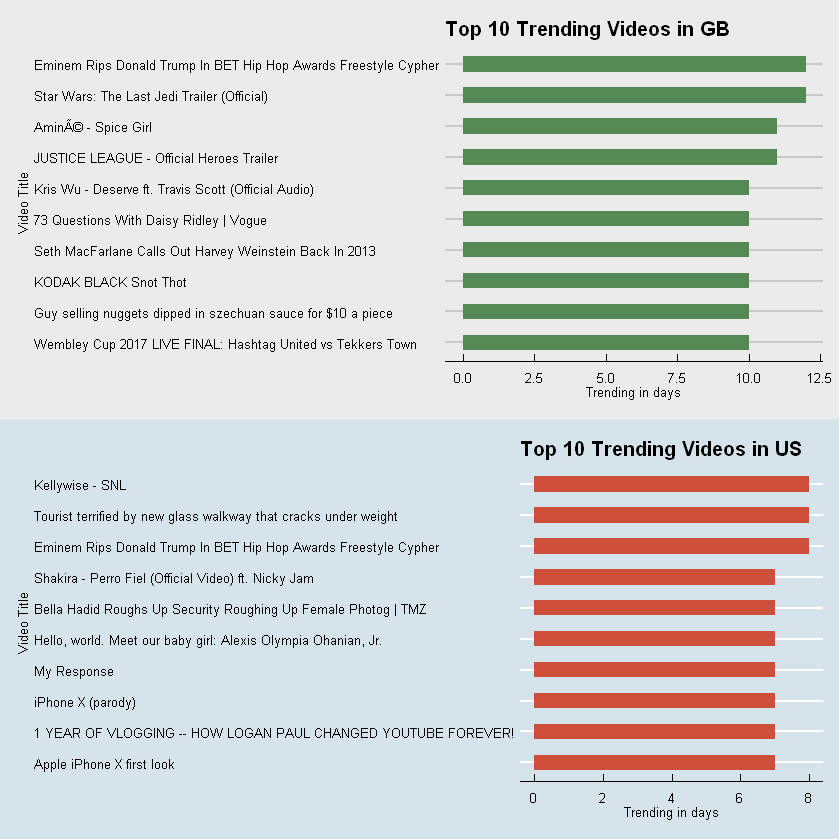

```r
# function for multi-line title
split_line <- function(sentence,n){
    wc <- wordcount(sentence)
    w <- word(sentence,1,n)
    if(wc <= n){
        return(sentence)
    }else{
        for(i in seq(n+1,wc,n)){
            start <- i
            end <- i+n
            if(wc == start){
                w <- paste(w, word(sentence, start),sep = ' \n ')
                return(w)
            }else if(wc < end){
                w <- paste(w, word(sentence, start, -1),sep = ' \n ')
                return(w)
            }else{
                w <- paste(w, word(sentence, start, end),sep = ' \n ')
            }

        }
        return(w)
    }

}


plot_data_gb <- unique_gb_videos %>% arrange(desc(trending_in_days)) %>% head(10)
plot_data_gb$title <- factor(plot_data_gb$title, levels = plot_data_gb$title[order(plot_data_gb$trending_in_days)])
p1<-ggplot(data=plot_data_gb, aes(x=title, y=trending_in_days)) +
  geom_bar(stat="identity", width=.5, fill="palegreen4") +
  xlab("Video Title") +
  ylab("Trending in days") +
  ggtitle("Top 10 Trending Videos in GB") +
  coord_flip() + theme_economist_white(base_size=8) + theme(panel.background = element_blank(),axis.text = element_text(size=8),axis.title=element_text(size=8))


plot_data_us <- unique_us_videos  %>% arrange(desc(trending_in_days)) %>% head(10)
plot_data_us$title <- factor(plot_data_us$title, levels = plot_data_us$title[order(plot_data_us$trending_in_days)])
p2<-ggplot(data=plot_data_us, aes(x=title, y=trending_in_days)) +
  geom_bar(stat="identity", width=.5, fill="tomato3") +
  xlab("Video Title") +
  ylab("Trending in days") +
  ggtitle("Top 10 Trending Videos in US") +
  coord_flip() + theme_economist(base_size = 8) + theme(panel.background = element_blank(),axis.text = element_text(size=8),axis.title=element_text(size=8))

grid.arrange(p1, p2, nrow = 2)
```

> The highest number of days a video was listed on the trending list in GB is 12 days and for US it's only 8 days. We can clearly see that GB and US have different top trending videos except the video titled *"Eminem Rips Donald Trump In BET Hip Hop Awards Freestyle Cypher"* which appears in both GB and US list.

**Top 10 trending channels**

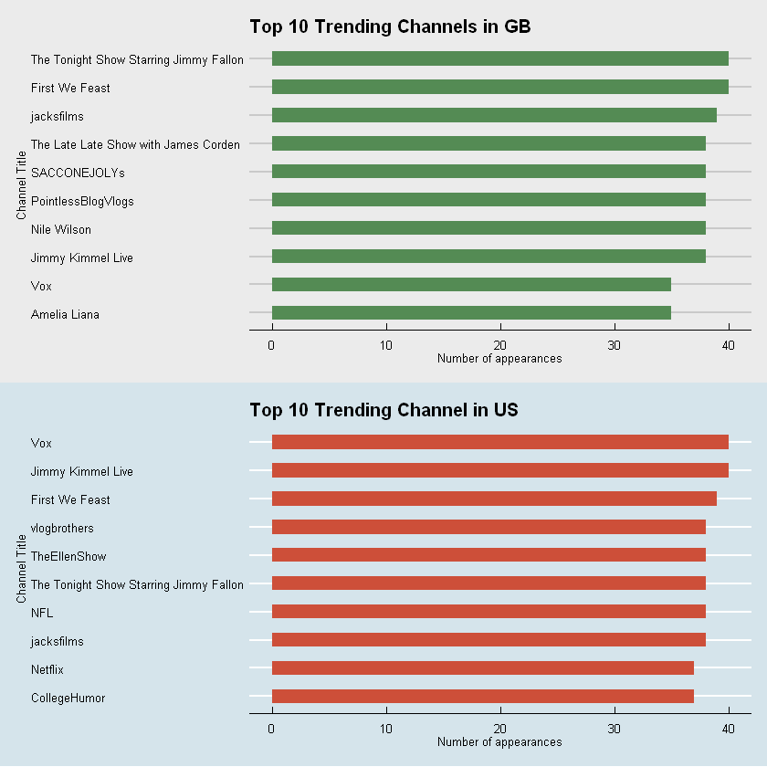

```r
plot_data_gb <- gb_videos %>% group_by(channel_title) %>%
  summarise(trending_count= n()) %>%
  arrange(desc(trending_count)) %>%
  head(10)

plot_data_gb$channel_title <- factor(plot_data_gb$channel_title, levels = plot_data_gb$channel_title[order(plot_data_gb$trending_count)])
p1<-ggplot(data=plot_data_gb, aes(x=channel_title, y=trending_count)) +
  geom_bar(stat="identity", width=.5, fill="palegreen4") +
  xlab("Channel Title") +
  ylab("Number of appearances") +
  ggtitle("Top 10 Trending Channels in GB") +
  coord_flip() + theme_economist_white(base_size=8) + theme(panel.background = element_blank(),axis.text = element_text(size=8),axis.title=element_text(size=8))

plot_data_us <- us_videos %>% group_by(channel_title) %>%
  summarise(trending_count = n()) %>%
  arrange(desc(trending_count)) %>%
  head(10)
plot_data_us$channel_title <- factor(plot_data_us$channel_title, levels = plot_data_us$channel_title[order(plot_data_us$trending_count)])
p2<-ggplot(data=plot_data_us, aes(x=channel_title, y=trending_count)) +
  geom_bar(stat="identity", width=.5, fill="tomato3") +
  xlab("Channel Title") +
  ylab("Number of appearances") +
  ggtitle("Top 10 Trending Channel in US") +
  coord_flip() +  theme_economist(base_size=8) + theme(panel.background = element_blank(),axis.text = element_text(size=8),axis.title=element_text(size=8))

grid.arrange(p1, p2, nrow = 2)
```

> 50% of the channels that appears in the GB top trending list also appears in the US list. From this plot we can also infer that only one video from each channel is allowed to be listed as trending video per day.

**Top 10 trending categories**

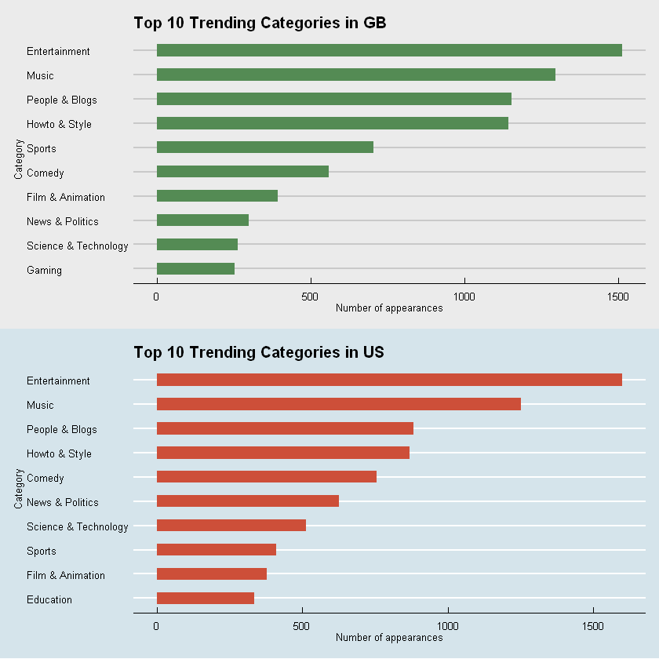

```r
plot_data_gb <- gb_videos %>% group_by(category) %>%
  summarise(trending_count = n()) %>%
  arrange(desc(trending_count)) %>%
  head(10)

plot_data_gb$category <- factor(plot_data_gb$category, levels = plot_data_gb$category[order(plot_data_gb$trending_count)])
p1<-ggplot(data=plot_data_gb, aes(x=category, y=trending_count)) +
  geom_bar(stat="identity", width=.5, fill="palegreen4") +
  xlab("Category") +
  ylab("Number of appearances") +
  ggtitle("Top 10 Trending Categories in GB") +
  coord_flip() + theme_economist_white(base_size=8) + theme(panel.background = element_blank(),axis.text = element_text(size=8),axis.title=element_text(size=8))

plot_data_us <- us_videos %>% group_by(category) %>%
  summarise(trending_count = n()) %>%
  arrange(desc(trending_count)) %>%
  head(10)

plot_data_us$category <- factor(plot_data_us$category, levels = plot_data_us$category[order(plot_data_us$trending_count)])
p2<-ggplot(data=plot_data_us, aes(x=category, y=trending_count)) +
  geom_bar(stat="identity", width=.5, fill="tomato3") +
  xlab("Category") +
  ylab("Number of appearances") +
  ggtitle("Top 10 Trending Categories in US") +
  coord_flip() + theme_economist(base_size=8) + theme(panel.background = element_blank(),axis.text = element_text(size=8),axis.title=element_text(size=8))

grid.arrange(p1, p2, nrow = 2)
```

> The frequency distribution of the categories appearing on the trending list are very similar in GB and US but it seems that GB audiences are more into sports videos and US audiences are more into news and politics.

**Most popular videos (based on no. of likes)**

```r
unique_gb_videos <- unique_gb_videos %>% mutate(popularity = (likes - dislikes))
popular_videos_gb <- unique_gb_videos %>% arrange(desc(popularity)) %>% head(10)
popular_videos_gb$title <- factor(popular_videos_gb$title, levels = popular_videos_gb$title[order(popular_videos_gb$popularity)])

plot_data_gb <- popular_videos_gb %>% select(c('title','likes','dislikes')) %>% melt(id='title')
plot_data_gb <- rename(plot_data_gb, Category = variable)

p1 <- ggplot(plot_data_gb, aes(x = title, y = value,fill = Category)) +
  xlab("Video Title") +
  ggtitle("Most liked Videos in GB") +
  geom_bar(stat = "identity", position = "stack") + coord_flip()
p1 <- ggplotly(p1)

htmlwidgets::saveWidget(p1, "plot.html")
display_html('<iframe src="plot.html" width=100% height=450 frameBorder="0"></iframe>')

unique_us_videos <- unique_us_videos %>% mutate(popularity = (likes - dislikes))
popular_videos_us <- unique_us_videos %>% arrange(desc(popularity)) %>% head(10)
popular_videos_us$title <- factor(popular_videos_us$title, levels = popular_videos_us$title[order(popular_videos_us$popularity)])

plot_data_us <- popular_videos_us %>% select(c('title','likes','dislikes')) %>% melt(id='title')
plot_data_us <- rename(plot_data_us, Category = variable)

p2 <- ggplot(plot_data_us, aes(x = title, y = value,fill = Category)) +
  xlab("Video Title") +
  ggtitle("Most liked Videos in US") +
  geom_bar(stat = "identity", position = "stack") + coord_flip()

p2 <- ggplotly(p2)
htmlwidgets::saveWidget(p2, "plot1.html")
display_html('<iframe src="plot1.html" width=100% height=450 frameBorder="0"></iframe>')
```

[interactive chart not shown]

> The most popular videos mostly made up of music videos. Although the video *"Eminem Rips Donald Trump In BET Hip Hop Awards Freestyle Cypher"* are highly trending, the amount of dislikes it gained are about 20% of the likes it gained.

**Top 10 popular channels (based on no. of likes)**

```r
popular_channel_gb <- unique_gb_videos %>% group_by(channel_title) %>%
  summarise(likes = sum(likes),dislikes = sum(dislikes),popularity = sum(popularity)) %>% arrange(desc(popularity)) %>% head(10)

popular_channel_gb$channel_title <- factor(popular_channel_gb$channel_title, levels = popular_channel_gb$channel_title[order(popular_channel_gb$popularity)])

plot_data_gb <- popular_channel_gb %>% select(c('channel_title','likes','dislikes')) %>% melt(id='channel_title')
plot_data_gb <- rename(plot_data_gb, Category = variable)

p1 <- ggplot(plot_data_gb, aes(x = channel_title, y = value,fill = Category)) +
  xlab("Channel Title") +
  ggtitle("Most Liked Channels in GB") +
  geom_bar(stat = "identity", position = "stack") + coord_flip()
p1 <- ggplotly(p1)
htmlwidgets::saveWidget(p1, "plot3.html")
display_html('<iframe src="plot3.html" width=100% height=450 frameBorder="0"></iframe>')

popular_channel_us <- unique_us_videos %>% group_by(channel_title) %>%
  summarise(likes = sum(likes),dislikes = sum(dislikes),popularity = sum(popularity)) %>% arrange(desc(popularity)) %>% head(10)

popular_channel_us$channel_title <- factor(popular_channel_us$channel_title, levels = popular_channel_us$channel_title[order(popular_channel_us$popularity)])

plot_data_us <- popular_channel_us %>% select(c('channel_title','likes','dislikes')) %>% melt(id='channel_title')
plot_data_us <- rename(plot_data_us, Category = variable)

p2 <- ggplot(plot_data_us, aes(x = channel_title, y = value,fill = Category)) +
  xlab("Channel Title") +
  ggtitle("Most Liked Channels in US") +
  geom_bar(stat = "identity", position = "stack") + coord_flip()
p2 <- ggplotly(p2)
htmlwidgets::saveWidget(p2, "plot4.html")
display_html('<iframe src="plot4.html" width=100% height=450 frameBorder="0"></iframe>')
```

[interactive chart not shown]

**Top 10 popular category (based on no. of likes)**

```r
popular_category_gb <- unique_gb_videos %>% group_by(category) %>%
  summarise(likes = sum(likes),dislikes = sum(dislikes),popularity = sum(popularity)) %>% arrange(desc(popularity)) %>% head(10)

popular_category_gb$category <- factor(popular_category_gb$category, levels = popular_category_gb$category[order(popular_category_gb$popularity)])

plot_data_gb <- popular_category_gb %>% select(c('category','likes','dislikes')) %>% melt(id='category')
plot_data_gb <- rename(plot_data_gb, Category = variable)
p1 <- ggplot(plot_data_gb, aes(x = category, y = value,fill = Category)) +
  xlab("Video Category") +
  ggtitle("Most Liked Video Categories in GB") +
  geom_bar(stat = "identity", position = "stack") + coord_flip()
p1 <- ggplotly(p1)
htmlwidgets::saveWidget(p1, "plot5.html")
display_html('<iframe src="plot5.html" width=100% height=450 frameBorder="0"></iframe>')

popular_category_us <- unique_us_videos %>% group_by(category) %>%
  summarise(likes = sum(likes),dislikes = sum(dislikes),popularity = sum(popularity)) %>% arrange(desc(popularity)) %>% head(10)

popular_category_us$category <- factor(popular_category_us$category, levels = popular_category_us$category[order(popular_category_us$popularity)])

plot_data_us <- popular_category_us %>% select(c('category','likes','dislikes')) %>% melt(id='category')
plot_data_us <- rename(plot_data_us, Category = variable)
p2 <- ggplot(plot_data_us, aes(x = category, y = value,fill = Category)) +
  xlab("Video Category") +
  ggtitle("Most Liked Video Categories in US") +
  geom_bar(stat = "identity", position = "stack") + coord_flip()
p2 <- ggplotly(p2)
htmlwidgets::saveWidget(p2, "plot6.html")
display_html('<iframe src="plot6.html" width=100% height=450 frameBorder="0"></iframe>')
```

[interactive chart not shown]

> In both GB and US, videos in **Music** category surpass videos in **Entertainment** category in popularity among audiences.

**Video tags wordcloud (GB vs US)**

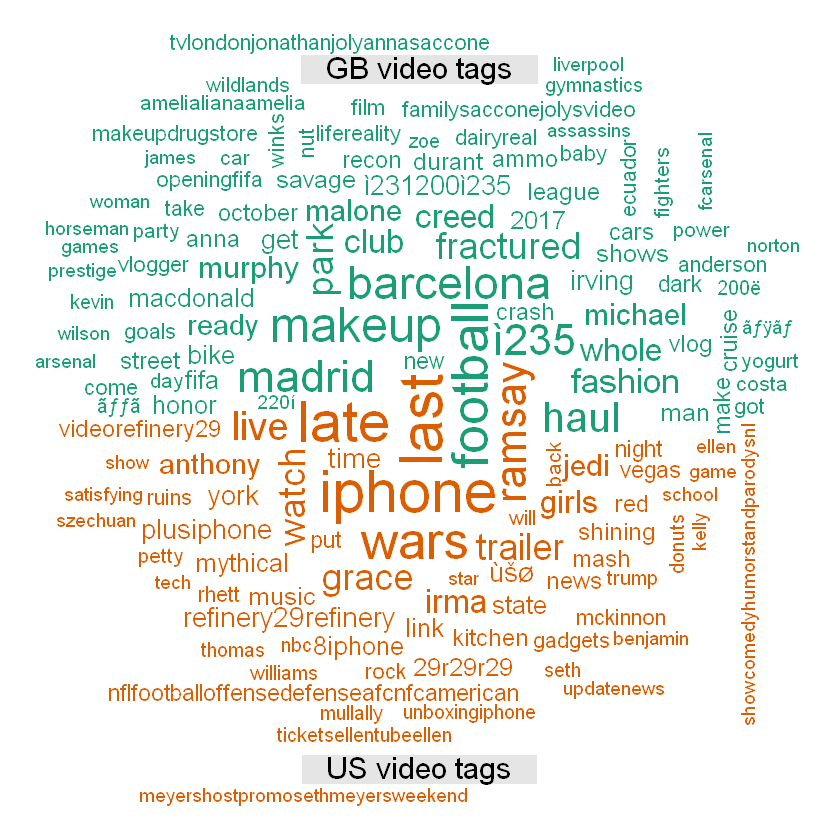

```r
tags <- c(unique_gb_videos['tags'],unique_us_videos['tags'])
videos_tag.Corpus<-Corpus(VectorSource(tags))

videos_tag.Clean<-tm_map(videos_tag.Corpus,tolower)
videos_tag.Clean<-tm_map(videos_tag.Clean,removeWords,stopwords("english"))
videos_tag.Clean<-tm_map(videos_tag.Clean,removePunctuation)
videos_tag.Clean<-tm_map(videos_tag.Clean,stripWhitespace)

# Create term-document matrix
tdm = TermDocumentMatrix(videos_tag.Clean)

# Convert as matrix
tdm = as.matrix(tdm)

# Add column names
colnames(tdm) = c('GB video tags','US video tags')

comparison.cloud(tdm, scale=c(3,.4), random.order=FALSE, colors = brewer.pal(8, "Dark2"), max.words=150,title.size =1.5)
```

> The video tags wordcloud reveals that trending videos listed in GB are mostly about *football* and *makeup*, while a lot of videos in US are tagged with words of *news*, *iphone* or *music*.

#### Distribution of views, likes, dislikes and comments in GB and US

**Views**

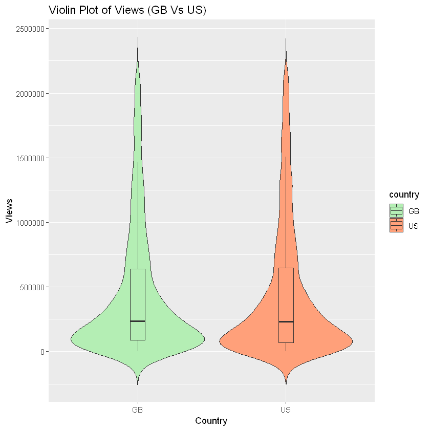

```r
plot_data <- unique_videos[!unique_videos$views %in% boxplot.stats(unique_videos$views)$out,]
p <-  ggplot(plot_data, aes(factor(country), views,fill = country)) + geom_violin(trim = FALSE) +
  geom_boxplot(width=.1, outlier.colour=NA) +
 xlab("Country") +
 ylab("Views") +
 ggtitle("Violin Plot of Views (GB Vs US)") +
 scale_fill_manual(values=c("GB"= "darkseagreen2","US"="lightsalmon"))
p
```

**Likes**

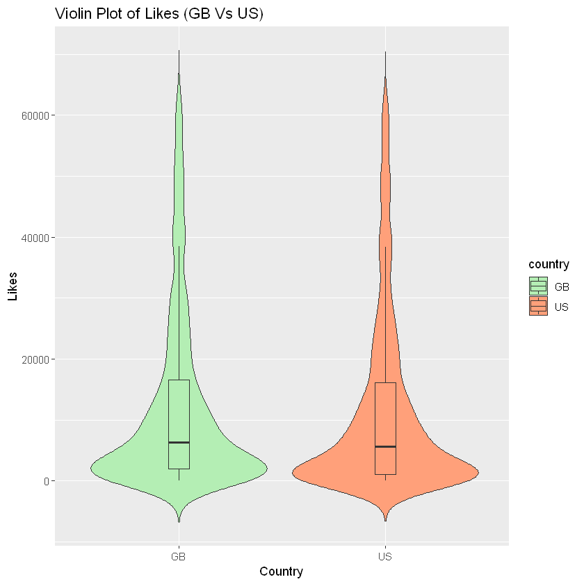

```r
plot_data <- unique_videos[!unique_videos$likes %in% boxplot.stats(unique_videos$likes)$out,]
p <-  ggplot(plot_data, aes(factor(country), likes,fill = country)) + geom_violin(trim = FALSE) +
  geom_boxplot(width=.1, outlier.colour=NA) +
 xlab("Country") +
 ylab("Likes") +
 ggtitle("Violin Plot of Likes (GB Vs US)") +
 scale_fill_manual(values=c("GB"= "darkseagreen2","US"="lightsalmon"))
p
```

**Dislikes**

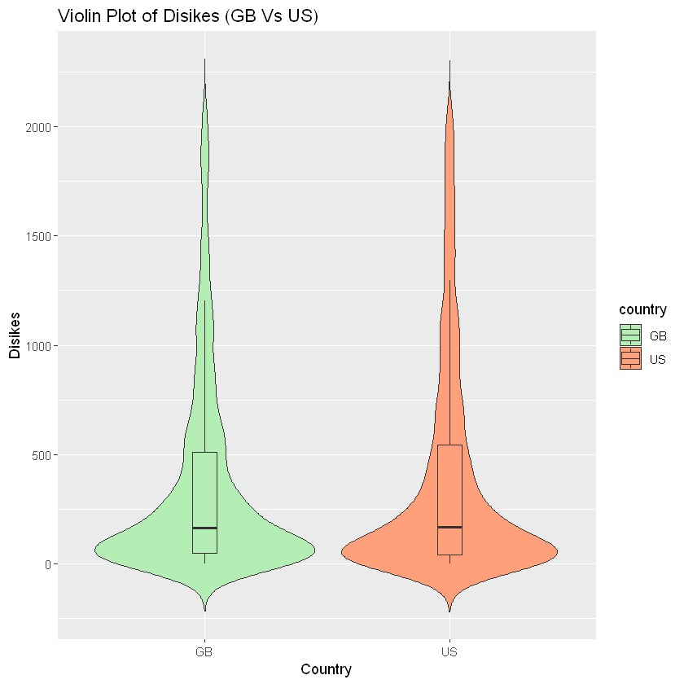

```r
plot_data <- unique_videos[!unique_videos$dislikes %in% boxplot.stats(unique_videos$dislikes)$out,]
p <-  ggplot(plot_data, aes(factor(country), dislikes,fill = country)) + geom_violin(trim = FALSE) +
  geom_boxplot(width=.1, outlier.colour=NA) +
 xlab("Country") +
 ylab("Disikes") +
 ggtitle("Violin Plot of Disikes (GB Vs US)") +
 scale_fill_manual(values=c("GB"= "darkseagreen2","US"="lightsalmon"))
p
```

**Comments**

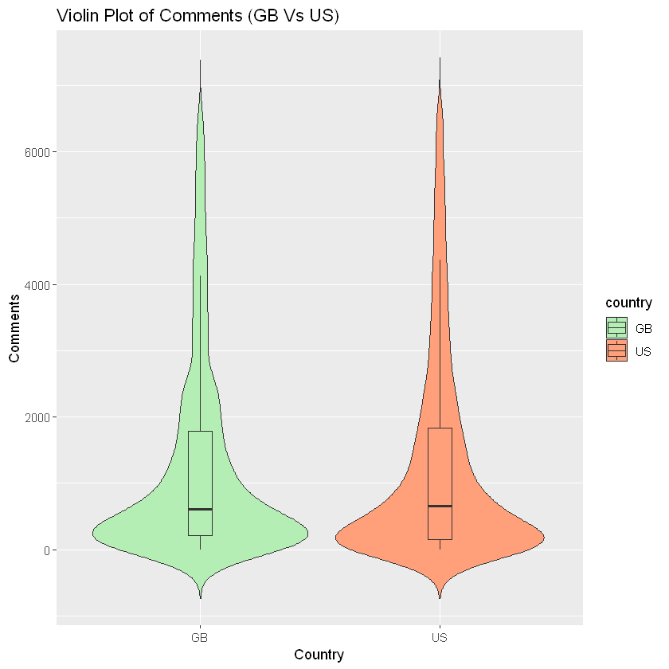

```r
plot_data <- unique_videos[!unique_videos$comment_total %in% boxplot.stats(unique_videos$comment_total)$out,]
p <-  ggplot(plot_data, aes(factor(country), comment_total,fill = country)) + geom_violin(trim = FALSE) +
  geom_boxplot(width=.1, outlier.colour=NA) +
 xlab("Country") +
 ylab("Comments") +
 ggtitle("Violin Plot of Comments (GB Vs US)") +
 scale_fill_manual(values=c("GB"= "darkseagreen2","US"="lightsalmon"))
p
```

### Sentiment Towards Videos

In Youtube, video viewers are given option to express their subjective opinions towards a video by writing and posting comments. The comments may be critical, suggestive, complimentary or even neutral, every one of it provides important information that help us to determine the audience sentiment or mood towards a particular video. Let's perform a simple sentiment analysis on the video comments using the comment dataset. For simplicity, we combine comments of every unique video and compute an overall sentiment score for the video.

Some preprocessing steps need to be done on the comment data as they are messy and unstructured. We should remove characters and words that are meaningless to our analysis.

```r
gb_comments <- gb_comments %>% filter(video_id %in% unique_gb_videos$video_id)

gb_videos_wo_comments <- unique_gb_videos %>% filter(!(video_id %in% unique(gb_comments$video_id)))

gb_comments_by_video_id <- gb_comments %>%
  group_by(video_id) %>%
  summarise(comment = paste(comment_text, collapse = " ")) %>%
  ungroup() %>%
  as.data.frame()
names(gb_comments_by_video_id) <- c('doc_id','text')
dfs <- DataframeSource(gb_comments_by_video_id)

# Cleaning GB comments corpus
gb_comments_corpus <- Corpus(dfs)
gb_comments_corpus<-tm_map(gb_comments_corpus,tolower)
gb_comments_corpus<-tm_map(gb_comments_corpus,content_transformer(replace_emoji))
gb_comments_corpus<-tm_map(gb_comments_corpus,content_transformer(replace_url))
gb_comments_corpus<-tm_map(gb_comments_corpus,content_transformer(replace_internet_slang))

sub_hyphen <- function(x) {
  gsub(x, pattern = "â€“", replacement = "-")
}
sub_apostrophe <- function(x) {
  gsub(x, pattern = "â€™", replacement = "'")
}

gb_comments_corpus<- tm_map(gb_comments_corpus,content_transformer(sub_hyphen))
gb_comments_corpus<- tm_map(gb_comments_corpus,content_transformer(sub_apostrophe))
gb_comments_corpus <- tm_map(gb_comments_corpus,removePunctuation,preserve_intra_word_contractions = TRUE,
                           preserve_intra_word_dashes = TRUE)
gb_comments_corpus <- tm_map(gb_comments_corpus,removeNumbers)
gb_comments_corpus <- tm_map(gb_comments_corpus,removeWords,stopwords("english"))
gb_comments_corpus <- tm_map(gb_comments_corpus,stripWhitespace)

# convert corpus into data frame
gb_comments_by_video_id <- data.frame(text=sapply(gb_comments_corpus, identity),stringsAsFactors=F)
gb_comments_by_video_id['video_id'] <- row.names(gb_comments_by_video_id)


us_comments <- us_comments %>% filter(video_id %in% unique_us_videos$video_id)
us_videos_wo_comments <- unique_us_videos %>% filter(!(video_id %in% unique(us_comments$video_id)))

us_comments_by_video_id <- us_comments %>%
  group_by(video_id) %>%
  summarise(comment = paste(comment_text, collapse = " ")) %>%
  ungroup() %>%
  as.data.frame()
names(us_comments_by_video_id) <- c('doc_id','text')
dfs <- DataframeSource(us_comments_by_video_id)
us_comments_corpus <- Corpus(dfs)

# Cleaning US comments corpus
us_comments_corpus<-tm_map(us_comments_corpus,tolower)
us_comments_corpus<-tm_map(us_comments_corpus,content_transformer(replace_emoji))
us_comments_corpus<-tm_map(us_comments_corpus,content_transformer(replace_url))
us_comments_corpus<-tm_map(us_comments_corpus,content_transformer(replace_internet_slang))
us_comments_corpus<- tm_map(us_comments_corpus,content_transformer(sub_hyphen))
us_comments_corpus<- tm_map(us_comments_corpus,content_transformer(sub_apostrophe))
us_comments_corpus <- tm_map(us_comments_corpus,removePunctuation,preserve_intra_word_contractions = TRUE,
                             preserve_intra_word_dashes = TRUE)
us_comments_corpus <- tm_map(us_comments_corpus,removeNumbers)
us_comments_corpus <- tm_map(us_comments_corpus,removeWords,stopwords("english"))
us_comments_corpus <- tm_map(us_comments_corpus,stripWhitespace)

# convert corpus into data frame
us_comments_by_video_id <- data.frame(text=sapply(us_comments_corpus, identity),stringsAsFactors=F)
us_comments_by_video_id['video_id'] <- row.names(us_comments_by_video_id)
```

```r
# Function to compute sentiment score
get_sentiment_scores <- function(df){
  length  <- dim(df)[1]
  n <- as.integer(length/500)
  counter <- 1

  for(i in seq(n)){
    text_vector <- df$text[counter:(counter+499)]
    df$sentiment_score[counter:(counter+499)] <- sentiment(text_vector)$sentiment
    counter <- counter+500
  }

  text_vector <- df$text[counter:length]
  df$sentiment_score[counter:length] <- sentiment(text_vector)$sentiment
  return(df)
}

# Get sentiment scores for GB videos
gb_comments_by_video_id['sentiment_score'] <- 0
gb_comments_by_video_id<- get_sentiment_scores(gb_comments_by_video_id)

# Get sentiment scores for US videos
us_comments_by_video_id['sentiment_score'] <- 0
us_comments_by_video_id<- get_sentiment_scores(us_comments_by_video_id)
```

**Comment Sentiment Score Distribution**

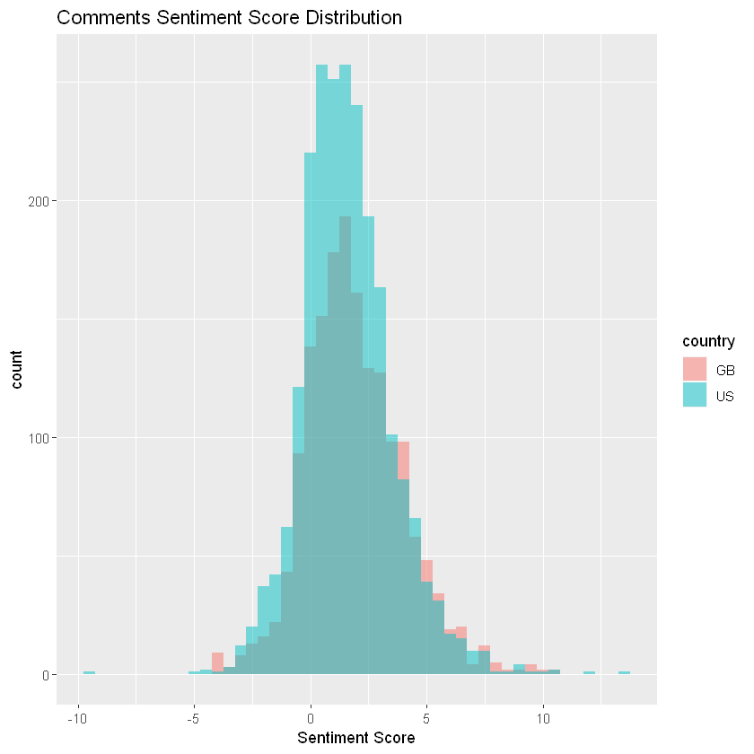

```r
unique_gb_videos <- unique_gb_videos %>% mutate(sentiment_score = mapvalues(video_id,from = gb_comments_by_video_id$video_id, to = gb_comments_by_video_id$sentiment_score))
unique_us_videos <- unique_us_videos %>% mutate(sentiment_score = mapvalues(video_id,from = us_comments_by_video_id$video_id, to = us_comments_by_video_id$sentiment_score))

unique_gb_videos <- unique_gb_videos %>% mutate(sentiment_score = replace(sentiment_score, video_id %in% gb_videos_wo_comments$video_id, NA))
unique_us_videos <- unique_us_videos %>% mutate(sentiment_score = replace(sentiment_score, video_id %in% us_videos_wo_comments$video_id, NA))

unique_videos <- rbind(unique_gb_videos,unique_us_videos)
unique_videos$sentiment_score <- as.numeric(unique_videos$sentiment_score)

p <- ggplot(unique_videos, aes(x=sentiment_score, fill=country)) +
    xlab("Sentiment Score") +
    ggtitle("Comments Sentiment Score Distribution") +
  geom_histogram(binwidth=.5, alpha=.5, position="identity")
p
```

> The sentiment score of GB and US trending videos both have a normal distribution and the mean is positive.

We can also categorize the sentiment score based on polarity:

- scores less than -1 : negative
- scores in the range of -1 to 1 : neutral
- scores more than 1 : positive

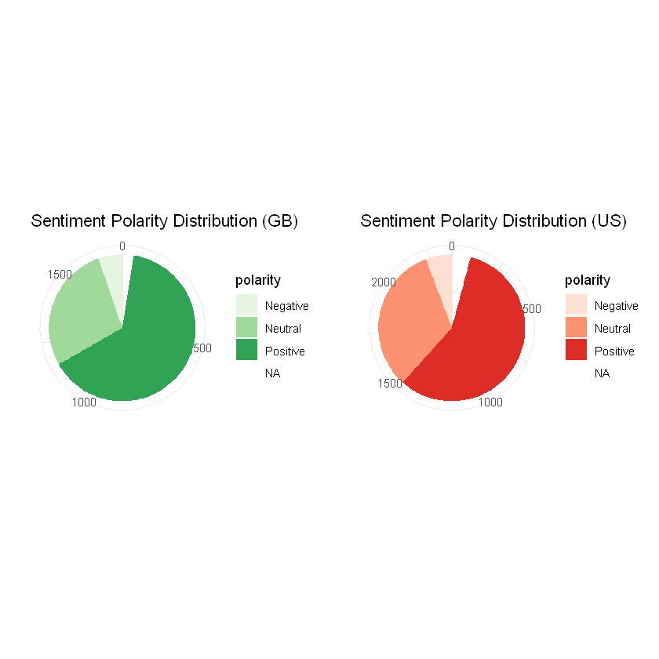

```r
# Add polarity
unique_videos <- unique_videos %>% mutate(polarity = ifelse(sentiment_score <= -1,'Negative',
                                                             ifelse(sentiment_score >= 1,'Positive','Neutral')))

plot_data_gb <- unique_videos %>% filter(country == 'GB') %>%
  group_by(polarity) %>% summarize(count = n())

p1 <- ggplot(plot_data_gb, aes(x="", y=count, fill=polarity))+
  geom_bar(width = 1, stat = "identity") +
  coord_polar("y", start=0) +
    xlab(" ") +
    ylab(" ") +
    ggtitle("Sentiment Polarity Distribution (GB)") +
  scale_fill_brewer(palette="Greens") +
  theme_minimal()

plot_data_us <- unique_videos %>% filter(country == 'US') %>%
  group_by(polarity) %>% summarize(count = n())

p2 <- ggplot(plot_data_us, aes(x="", y=count, fill=polarity))+
  geom_bar(width = 1, stat = "identity") +
  coord_polar("y", start=0) +
    xlab(" ") +
    ylab(" ") +
    ggtitle("Sentiment Polarity Distribution (US)") +
  scale_fill_brewer(palette="Reds") +
  theme_minimal()


grid.arrange(p1, p2, nrow = 1)
```

**Sentiment Scores By Categories**

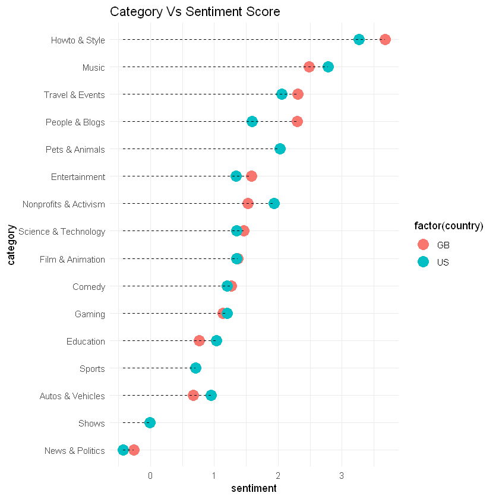

```r
plot_data <- unique_videos %>%
            group_by(category,country) %>%
            summarize(sentiment = mean(sentiment_score,na.rm = TRUE))

factor_data <- plot_data %>% distinct(category,.keep_all=TRUE) %>% arrange(sentiment)

plot_data$category <- factor(plot_data$category, levels = factor_data$category)

ggplot(plot_data, aes(x=category, y=sentiment)) +
  geom_point(aes(colour = factor(country)), size=5) +
  geom_segment(aes(x=category,
                   xend=category,
                   y=min(sentiment),
                   yend=sentiment),
               linetype="dashed",
               size=0.1) +
  ggtitle("Category Vs Sentiment Score") +
  coord_flip()+
  theme_minimal()
```

> *Howto & Style* category has the highest postive sentiment, followed by *Music* and *Travel & Event*. *News & Politics* received the strongest negative attitudes from the audiences.

**Top 10 videos based on sentiment scores**

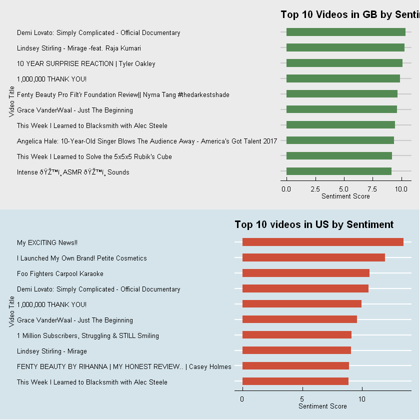

```r
plot_data_gb <- unique_videos %>% filter(country == 'GB') %>%
  arrange(desc(sentiment_score)) %>% head(10)
plot_data_gb$title <- factor(plot_data_gb$title, levels = plot_data_gb$title[order(plot_data_gb$sentiment_score)])
p1<-ggplot(data=plot_data_gb, aes(x=title, y=sentiment_score)) +
  geom_bar(stat="identity", width=.5, fill="palegreen4") +
  xlab("Video Title") +
  ylab("Sentiment Score") +
  ggtitle("Top 10 Videos in GB by Sentiment") +
  coord_flip() + theme_economist_white(base_size = 8) + theme(panel.background = element_blank(),axis.text = element_text(size=8),axis.title=element_text(size=8))

plot_data_us <- unique_videos %>% filter(country == 'US') %>%
  arrange(desc(sentiment_score)) %>% head(10)
plot_data_us$title <- factor(plot_data_us$title, levels = plot_data_us$title[order(plot_data_us$sentiment_score)])
p2<-ggplot(data=plot_data_us, aes(x=title, y=sentiment_score)) +
    geom_bar(stat="identity", width=.5, fill="tomato3") +
  xlab("Video Title") +
  ylab("Sentiment Score") +
  ggtitle("Top 10 videos in US by Sentiment") +
  coord_flip() + theme_economist(base_size = 8) + theme(panel.background = element_blank(),axis.text = element_text(size=8),axis.title=element_text(size=8))

grid.arrange(p1, p2, nrow = 2)
```

**Sentiment Score Vs Likes**

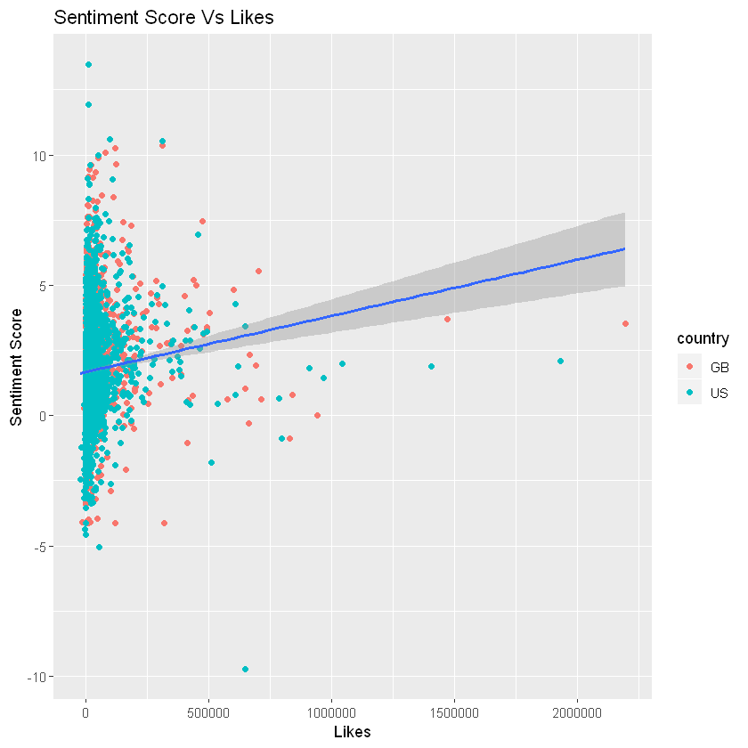

```r
unique_videos <- unique_videos %>% mutate(total_likes = likes-dislikes)
p <- ggplot(unique_videos, aes(x=total_likes, y=sentiment_score)) +
  geom_point(aes(col=country)) +  geom_smooth(method = lm) +
  xlab('Likes') +
  ylab('Sentiment Score') +
  ggtitle('Sentiment Score Vs Likes')
p
```

The scoring system used in this analysis is fairly simple in design but it does give an general assumption of the sentiment. However, we can further improve the precision of the score by introducing a **weighting scheme** into the system in which the sentiment will be weighted based on the **usefulness** of a particular comment denoted by its number of replies and likes.

### A deeper look into top trending videos

We can gain more insights by analyzing the features of the top trending videos. We will be using videos that are being in trend for more than 8 days for GB and 5 days for US.

```r
top_trending_videos_gb <- unique_gb_videos %>% filter(trending_in_days >8)
top_trending_videos_us <- unique_us_videos %>% filter(trending_in_days >5)
```

**Top Trending video Tags Wordcloud (GB)**

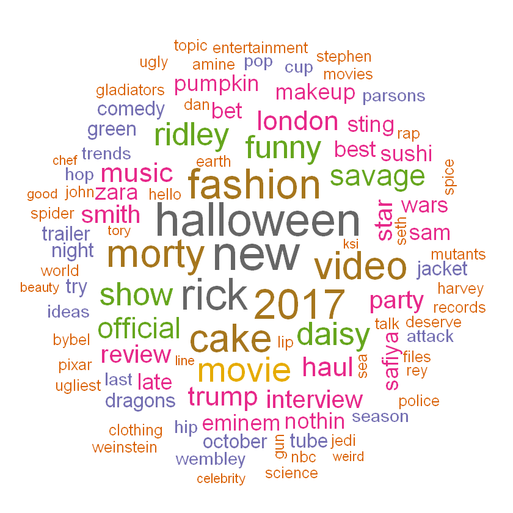

```r
gb_videos_tag.Corpus<-Corpus(VectorSource(c(top_trending_videos_gb['tags'])))

gb_videos_tag.Clean<-tm_map(gb_videos_tag.Corpus,tolower)
gb_videos_tag.Clean<-tm_map(gb_videos_tag.Clean,removeWords,stopwords("english"))

gb_videos_tdm <- TermDocumentMatrix(gb_videos_tag.Clean)

gb_videos_tdm <- as.matrix(gb_videos_tdm)

colnames(gb_videos_tdm) <- c('GB')

wordcloud(words = row.names(gb_videos_tdm),freq = gb_videos_tdm[,1],
          min.freq = 1,max.words=100, random.order=FALSE,
          colors=brewer.pal(8, "Dark2"))
```

> Interestingly, there is hardly any videos tags about *football* among the top trending videos in GB. The high frequency of the term *halloween* can be explained by the celebration of Halloween Day during October.

**Top Trending video Tags Wordcloud (US)**

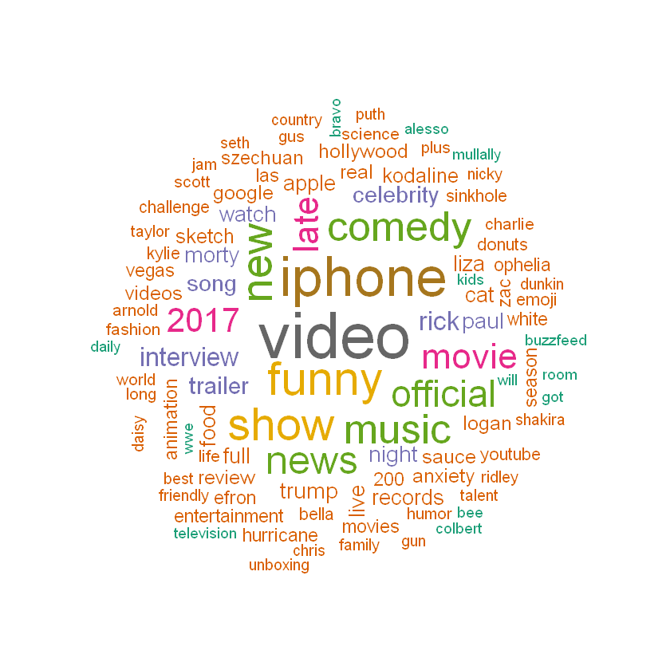

```r
us_videos_tag.Corpus<-Corpus(VectorSource(c(top_trending_videos_us['tags'])))

us_videos_tag.Clean<-tm_map(us_videos_tag.Corpus,tolower)
us_videos_tag.Clean<-tm_map(us_videos_tag.Clean,removeWords,stopwords("english"))

us_videos_tdm <- TermDocumentMatrix(us_videos_tag.Clean)

us_videos_tdm <- as.matrix(us_videos_tdm)

colnames(us_videos_tdm) <- c('US')

wordcloud(words = row.names(us_videos_tdm),freq = us_videos_tdm[,1],
          min.freq = 1,max.words=100, random.order=FALSE,
          colors=brewer.pal(8, "Dark2"))
```

> The term *iphone* is emphasized again.

**Top Trending Videos Sentiment Distribution**

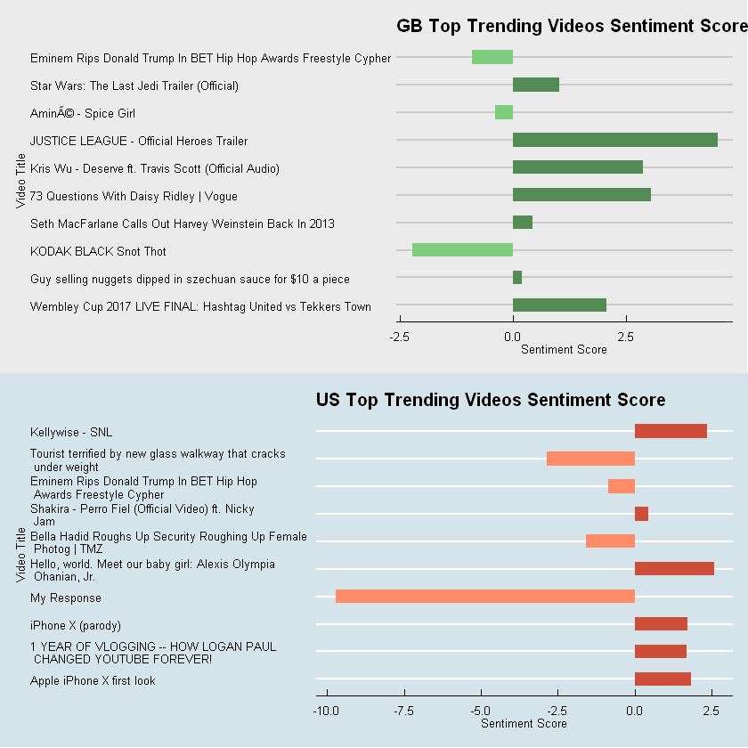

```r
top_10_trending_videos_gb <- unique_gb_videos %>% arrange(desc(trending_in_days)) %>% head(10)
top_10_trending_videos_us <- unique_us_videos %>% arrange(desc(trending_in_days)) %>% head(10)

plot_data_gb <- unique_videos %>% filter(country == 'GB' & video_id %in% top_10_trending_videos_gb$video_id)
plot_data_gb$colour <- ifelse(plot_data_gb$sentiment_score<0, "palegreen3", "palegreen4")

plot_data_gb$title <- factor(plot_data_gb$title, levels = plot_data_gb$title[order(plot_data_gb$trending_in_days)])
p1<-ggplot(data=plot_data_gb, aes(x=title, y=sentiment_score,fill=colour)) +
  geom_bar(stat="identity", width=.5) +
  xlab("Video Title") +
  ylab("Sentiment Score") +
  ggtitle("GB Top Trending Videos Sentiment Score") +
  coord_flip() + theme_economist_white(base_size = 8) + theme(panel.background = element_blank(),axis.text = element_text(size=8),axis.title=element_text(size=8),legend.position="none") +
  scale_fill_manual(values=c("palegreen3"= "palegreen3","palegreen4"="palegreen4"))


plot_data_us <- unique_videos %>% filter(country == 'US'& video_id %in% top_10_trending_videos_us$video_id)
plot_data_us$colour <- ifelse(plot_data_us$sentiment_score < 0, "salmon1", "tomato3")
plot_data_us$title <- sapply(plot_data_us$title, split_line,n=8)
plot_data_us$title <- factor(plot_data_us$title, levels = plot_data_us$title[order(plot_data_us$trending_in_days)])

p2<-ggplot(data=plot_data_us, aes(x=title, y=sentiment_score, fill=colour)) +
  geom_bar(stat="identity", width=.5) +
  xlab("Video Title") +
  ylab("Sentiment Score") +
  ggtitle("US Top Trending Videos Sentiment Score") +
  coord_flip() + theme_economist(base_size = 8) + theme(panel.background = element_blank(),axis.text = element_text(size=8),axis.title=element_text(size=8),legend.position="none") +
  scale_fill_manual(values=c("salmon1"= "salmon1","tomato3"="tomato3"))

grid.arrange(p1, p2, nrow = 2)
```

> From the plot we can see that some of these top trending videos are not always everyone's favorites.

Another factor we can try to look at is the percentage change of the video statistics over time. We can make a rough estimation of the growing speed by calculate the relative growth rate for each video using views, likes, dislikes and comments.

```r
trending_gb_videos <- unique_gb_videos %>% arrange(desc(trending_in_days)) %>% head(10)
trending_us_videos <- unique_us_videos %>% arrange(desc(trending_in_days)) %>% head(10)
gb_videos <- gb_videos  %>%  mutate(VLDC = views+ likes+ dislikes+ comment_total)

plot_data_gb <- gb_videos %>% group_by(video_id) %>%
    summarise(r_growth_rate = ((log(last(VLDC, order_by = date)) - log(first(VLDC, order_by = date)))/(n() - 1)) *100) %>%
    mutate(title = mapvalues(video_id,from = unique_gb_videos$video_id, to = unique_gb_videos$title),
           trending_in_days = mapvalues(video_id,from = unique_gb_videos$video_id, to = unique_gb_videos$trending_in_days))
plot_data_gb$trending_in_days <- as.integer(plot_data_gb$trending_in_days)

unique_gb_videos$r_growth_rate = mapvalues(unique_gb_videos$video_id,from = plot_data_gb$video_id, to = plot_data_gb$r_growth_rate)

us_videos <- us_videos  %>%  mutate(VLDC = views+ likes+ dislikes+ comment_total)

plot_data_us <- us_videos %>% group_by(video_id) %>%
  summarise(r_growth_rate = ((log(last(VLDC, order_by = date)) - log(first(VLDC, order_by = date)))/(n() - 1)) *100) %>%
  mutate(title = mapvalues(video_id,from = unique_us_videos$video_id, to = unique_us_videos$title),
         trending_in_days = mapvalues(video_id,from = unique_us_videos$video_id, to = unique_us_videos$trending_in_days))
plot_data_us$trending_in_days <- as.integer(plot_data_us$trending_in_days)

unique_us_videos$r_growth_rate = mapvalues(unique_us_videos$video_id,from = plot_data_us$video_id, to = plot_data_us$r_growth_rate)
```

**Violin plot of relative growth rate**

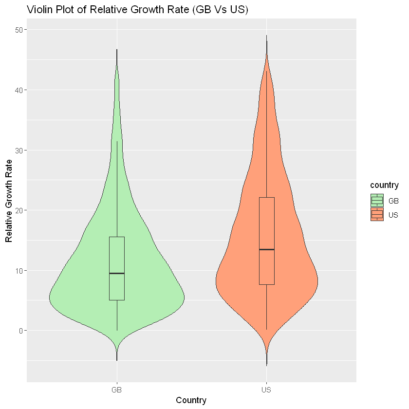

```r
unique_videos <- rbind(unique_gb_videos,unique_us_videos)
unique_videos$r_growth_rate <- as.numeric(unique_videos$r_growth_rate)
plot_data <- unique_videos[!unique_videos$r_growth_rate %in% boxplot.stats(unique_videos$r_growth_rate)$out,]
p <-  ggplot(plot_data, aes(factor(country), r_growth_rate,fill = country)) + geom_violin(trim = FALSE) +
  geom_boxplot(width=.1, outlier.colour=NA)  +
 xlab("Country") +
 ylab("Relative Growth Rate") +
 ggtitle("Violin Plot of Relative Growth Rate (GB Vs US)") +
 scale_fill_manual(values=c("GB"= "darkseagreen2","US"="lightsalmon"))
p
```

> In average, the US trending videos are more fast-growing than GB trending videos.

**Trending in Days Vs Relative Growth Rate Scatter Plot**

Let's try to check the relationship between the growth rate and the number of days in trend. Top trending videos are highlighted in the following plots.

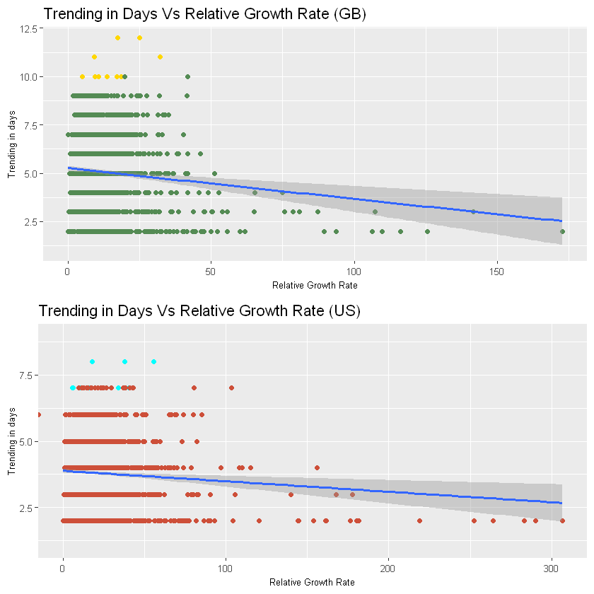

```r
plot_data_gb$top_trending <- ifelse((plot_data_gb$video_id %in% top_10_trending_videos_gb$video_id), "yes", "no")
plot_data_gb <- plot_data_gb %>% arrange(desc(top_trending))
p1 <- ggplot(plot_data_gb, aes(x=r_growth_rate, y=trending_in_days)) +
  geom_point(aes(colour = factor(top_trending))) +  geom_smooth(method = lm) +
  xlab('Relative Growth Rate') +
  ylab('Trending in days') +
  ggtitle('Trending in Days Vs Relative Growth Rate (GB)') +
  theme(axis.text = element_text(size=8),axis.title=element_text(size=8),legend.position="none") +
    scale_color_manual(values=c("yes"= "gold1","no" = "palegreen4"))

plot_data_us$top_trending <- ifelse((plot_data_us$video_id %in% top_10_trending_videos_us$video_id), "yes", "no")
plot_data_us <- plot_data_us %>% arrange(desc(top_trending))
p2 <- ggplot(plot_data_us, aes(x=r_growth_rate, y=trending_in_days)) +
  geom_point(aes(colour = factor(top_trending))) +  geom_smooth(method = lm) +
  xlab('Relative Growth Rate') +
  ylab('Trending in days') +
  ggtitle('Trending in Days Vs Relative Growth Rate (US)') +
  theme(axis.text = element_text(size=8),axis.title=element_text(size=8),legend.position="none") +
    scale_color_manual(values=c("yes"= "cyan","no"="tomato3"))

grid.arrange(p1, p2, nrow = 2)
```

> Genrally, the top trending videos are growing slow and steady.

**Trending in Days Vs Relative Growth Rate Boxplot**

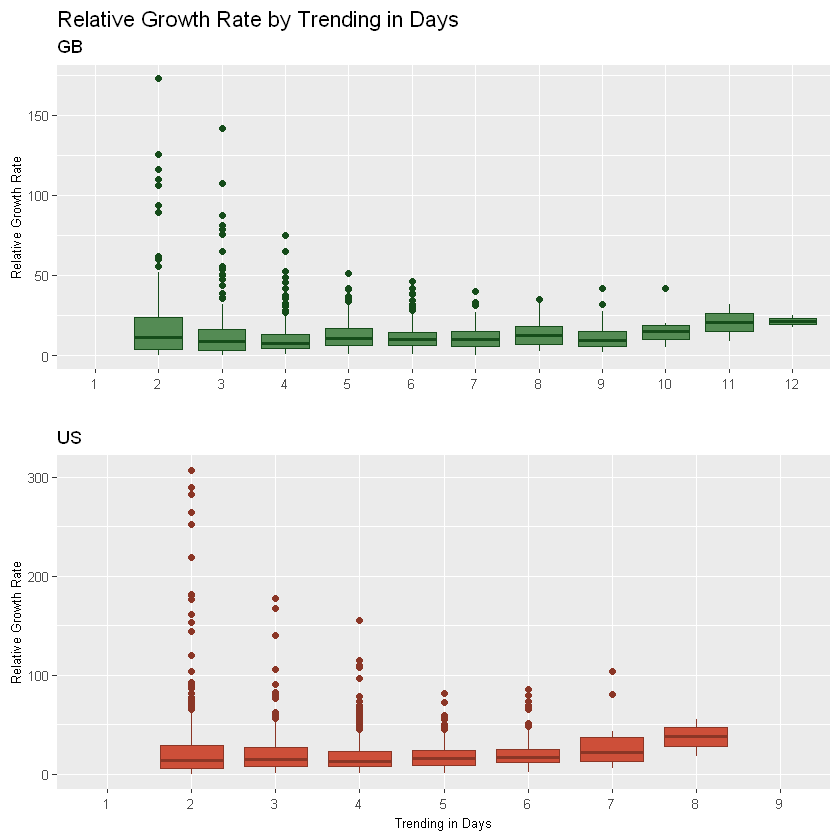

```r
plot_data_gb$trending_in_days <- factor(plot_data_gb$trending_in_days)
plot_data_us$trending_in_days <- factor(plot_data_us$trending_in_days)

p1 <- ggplot(plot_data_gb, aes(x=trending_in_days, y=r_growth_rate)) +
    geom_boxplot(fill="palegreen4",color ="#154c1a") +
    xlab(' ') +
    ylab('Relative Growth Rate') +
    labs(title = "Relative Growth Rate by Trending in Days",subtitle = "GB") +
   theme(axis.text = element_text(size=8),axis.title=element_text(size=8))

p2 <- ggplot(plot_data_us, aes(x=trending_in_days, y=r_growth_rate)) +
  geom_boxplot(fill="tomato3",color ="tomato4") +
    xlab('Trending in Days') +
    ylab('Relative Growth Rate') +
    labs(subtitle = "US") +
    theme(axis.text = element_text(size=8),axis.title=element_text(size=8))

grid.arrange(p1, p2, nrow = 2)
```

### Features Correlation

Here we plot a correlation heatmap to depict the relationship between features.

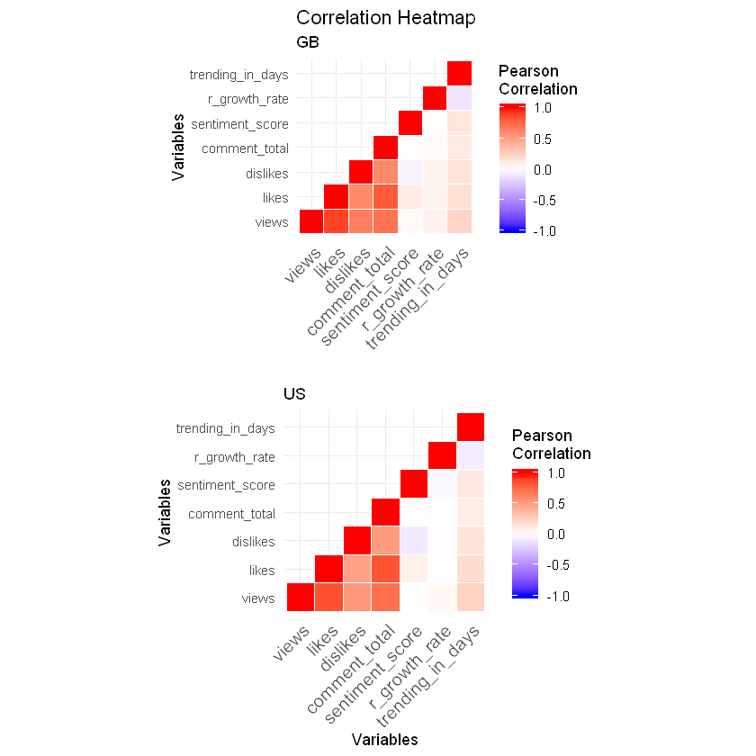

```r
corrdata <- unique_gb_videos %>% select(c(views, likes, dislikes, comment_total,sentiment_score,r_growth_rate,trending_in_days))

corrdata$sentiment_score <- as.numeric(corrdata$sentiment_score)
corrdata$r_growth_rate <- as.numeric(corrdata$r_growth_rate)

cormat <- cor(corrdata, use = "complete.obs")

get_upper_tri <- function(cormat){
    cormat[lower.tri(cormat)]<- NA
    return(cormat)
  }

upper_tri <- get_upper_tri(cormat)

plot_data_gb <- melt(upper_tri, na.rm = TRUE)

p1 <- ggplot(data = plot_data_gb, aes(Var2, Var1, fill = value))+
  geom_tile(color = "white")+
  xlab(' ') +
  ylab('Variables') +
  labs(title = "Correlation Heatmap",subtitle = "GB") +
  scale_fill_gradient2(low = "blue", high = "red", mid = "white",
                       midpoint = 0, limit = c(-1,1), space = "Lab",
                       name="Pearson\nCorrelation") +
  theme_minimal()+
  theme(axis.text.x = element_text(angle = 45, vjust = 1,
                                   size = 12, hjust = 1))+
  coord_fixed()

corrdata <- unique_us_videos %>% select(c(views, likes, dislikes, comment_total,sentiment_score,r_growth_rate,trending_in_days))

corrdata$sentiment_score <- as.numeric(corrdata$sentiment_score)
corrdata$r_growth_rate <- as.numeric(corrdata$r_growth_rate)

cormat <- cor(corrdata, use = "complete.obs")

upper_tri <- get_upper_tri(cormat)

plot_data_us <- melt(upper_tri, na.rm = TRUE)

p2 <- ggplot(data = plot_data_us, aes(Var2, Var1, fill = value))+
  geom_tile(color = "white")+
  xlab('Variables') +
  ylab('Variables') +
  labs(subtitle = "US") +
  scale_fill_gradient2(low = "blue", high = "red", mid = "white",
                       midpoint = 0, limit = c(-1,1), space = "Lab",
                       name="Pearson\nCorrelation") +
  theme_minimal()+
  theme(axis.text.x = element_text(angle = 45, vjust = 1,
                                   size = 12, hjust = 1))+
  coord_fixed()

grid.arrange(p1, p2, nrow = 2)
```

> Summary:
> - Trending videos generally have considerable amount of views, likes and comments.
> - Amount of views, likes and comments have strong positive correlations.
> - The higher the amount of dislike, the lower the sentiment score.
> - Videos in category **music** and **entertainment** has higher chance to be listed on trending video list.
> - Videos related to major events such as launching of a new iphone, a new album release, election and festival are more likely to stay in trend for longer period of time.

**Popular videos in GB**

```r
top_10_percent_gb <- as.integer(dim(unique_gb_videos)[1] *10/100)

top_trending_gb_videos <- unique_gb_videos %>% arrange(desc(trending_in_days)) %>% head(top_10_percent_gb)
top_liked_gb_videos <- unique_gb_videos %>% arrange(desc(likes)) %>% head(top_10_percent_gb)
top_sentiment_gb_videos <- unique_gb_videos %>% arrange(desc(sentiment_score)) %>% head(top_10_percent_gb)

common <- intersect(top_trending_gb_videos$video_id, intersect(top_liked_gb_videos$video_id,top_sentiment_gb_videos$video_id))
top_gb_videos <- unique_gb_videos[unique_gb_videos$video_id %in% common,]
top_gb_videos$sentiment_score <- as.numeric(top_gb_videos$sentiment_score)
top_10_percent_us <- as.integer(dim(unique_us_videos)[1] *10/100)

top_trending_us_videos <- unique_us_videos %>% arrange(desc(trending_in_days)) %>% head(top_10_percent_us)
top_liked_us_videos <- unique_us_videos %>% arrange(desc(likes)) %>% head(top_10_percent_us)
top_sentiment_us_videos <- unique_us_videos %>% arrange(desc(sentiment_score)) %>% head(top_10_percent_us)

common <- intersect(top_trending_us_videos$video_id, intersect(top_liked_us_videos$video_id,top_sentiment_us_videos$video_id))
top_us_videos <- unique_us_videos[unique_us_videos$video_id %in% common,]
top_us_videos$sentiment_score <- as.numeric(top_us_videos$sentiment_score)

common <- intersect(top_gb_videos$video_id,top_us_videos$video_id)
top_videos <- unique_gb_videos[unique_gb_videos$video_id %in% common,]
top_videos$sentiment_score <- as.numeric(top_videos$sentiment_score)
```

```r
display_html(as.character(top_gb_videos %>%
                          select(title,likes,trending_in_days,sentiment_score) %>%
                          mutate_if(is.numeric, function(x) {
                            cell_spec(x, bold = T,
                                      color = spec_color(x, end = 0.9),
                                      font_size = spec_font_size(x))
                          }) %>%
                          kable(escape = F, align = "c") %>%
                          kable_styling(c("striped", "condensed"), full_width = F)
                         )
            )
```

| title | likes | trending_in_days | sentiment_score |
| --- | --- | --- | --- |
| Lana Del Rey - White Mustang (Official Video) | 291067 | 9 | 5.17179427621003 |
| We need to talk | 145104 | 8 | 5.80626208700136 |
| Zedd, Liam Payne - Get Low (Street Video) | 204861 | 8 | 4.86577614609694 |
| Sam Smith - Too Good At Goodbyes (Official Video) | 615290 | 9 | 4.8244612225034 |
| Maroon 5 - What Lovers Do ft. SZA | 268285 | 8 | 4.70219847559516 |
| Imagine Dragons - Whatever It Takes | 708905 | 9 | 5.55492609478248 |

**Popular videos in US**

```r
display_html(as.character(top_us_videos %>%
                          select(title,likes,trending_in_days,sentiment_score) %>%
                          mutate_if(is.numeric, function(x) {
                            cell_spec(x, bold = T,
                                      color = spec_color(x, end = 0.9),
                                      font_size = spec_font_size(x))
                          }) %>%
                          kable(escape = F, align = "c") %>%
                          kable_styling(c("striped", "condensed"), full_width = F)
                         )
            )
```

| title | likes | trending_in_days | sentiment_score |
| --- | --- | --- | --- |
| Imagine Dragons - Whatever It Takes (360 Version/Lyric Video) | 83346 | 5 | 4.75040585338826 |
| Lana Del Rey - White Mustang (Official Video) | 273916 | 6 | 4.27371163442348 |
| My Boyfriend Buys My Outfits | 175347 | 6 | 4.52033685665654 |
| The Try Guys Get Makeovers From High School Girls | 176573 | 6 | 4.15637128391914 |
| We need to talk | 144182 | 6 | 5.47936705175075 |
| Ed Sheeran - Perfect [Official Lyric Video] | 461378 | 6 | 6.94189024703289 |
| P!nk - Beautiful Trauma (Audio) | 82045 | 6 | 6.12030905189 |
| Charlie Puth – How Long [Official Audio] | 185837 | 7 | 4.15292697515497 |
| Rudy Mancuso & Poo Bear - Black & White (Official Video) | 181332 | 6 | 6.52153358533648 |
| Lindsey Stirling - Mirage | 111709 | 6 | 9.05635399410566 |
| Jessie J - Not My Ex | 180008 | 6 | 5.86897747859841 |

**Popular Videos in both GB and US**

```r
display_html(as.character(top_videos %>%
                          select(title,likes,trending_in_days,sentiment_score) %>%
                          mutate(title = cell_spec(
                            title, color = "white", background="red", bold = T
                          )) %>%
                          kable(escape = F, align = "c") %>%
                          kable_styling(c("striped", "condensed"), full_width = F,font_size = 15)
                         )
            )
```

| title | likes | trending_in_days | sentiment_score |
| --- | --- | --- | --- |
| Lana Del Rey - White Mustang (Official Video) | 291067 | 9 | 5.171794 |
| We need to talk | 145104 | 8 | 5.806262 |